# 机器学习-分类

Studennt. LI Junjie

Dongbei University of Finance & Economics

2020-07-13

# 1 加载经常用的R包

```r
library(pacman)
# 读数据
p_load(readxl,writexl,data.table,openxlsx,haven,rvest)
```

```r
# 数据探索
p_load(tidyverse,DT,skimr,DataExplorer,explore,vtable,stringr,kableExtra,lubridate)
```

```r
# 模型
p_load(grf,glmnet,caret,tidytext,fpp2,forecast,car,tseries,hdm,tidymodels,broom)
```

```r
# 可视化
p_load(patchwork,ggrepel,ggcorrplot,gghighlight,ggthemes,shiny)
```

```r
# 其它常用包
p_load(magrittr,listviewer,devtools,here,janitor,reticulate,jsonlite)
p_load("rpart", "rpart.plot", "party","randomForest", "e1071")
```

# 2 数据准备

本数据集包含699个细针抽吸活检的样本单元，其中458个（65.5%）为良性样本单元， 241个（34.5%）为恶性样本单元。数据集中共有11个变量，表中未标明变量名。共有16个样本单元中有缺失数据并用问号（?）表示。

```r
read.csv(here::here("Statistics/breast.csv")) -> data
data %<>% select(-1)
```

```r
data %>% head()
```

|  | V1 | V2 | V3 | V4 | V5 | V6 | V7 | V8 | V9 | V10 | V11 |
| --- | --- | --- | --- | --- | --- | --- | --- | --- | --- | --- | --- |
| 1 | 1000025 | 5 | 1 | 1 | 1 | 2 | 1 | 3 | 1 | 1 | 2 |
| 2 | 1002945 | 5 | 4 | 4 | 5 | 7 | 10 | 3 | 2 | 1 | 2 |
| 3 | 1015425 | 3 | 1 | 1 | 1 | 2 | 2 | 3 | 1 | 1 | 2 |
| 4 | 1016277 | 6 | 8 | 8 | 1 | 3 | 4 | 3 | 7 | 1 | 2 |
| 5 | 1017023 | 4 | 1 | 1 | 3 | 2 | 1 | 3 | 1 | 1 | 2 |
| 6 | 1017122 | 8 | 10 | 10 | 8 | 7 | 10 | 9 | 7 | 1 | 4 |

```r
data %>% is.na() %>% sum()
```

```
## [1] 16
```

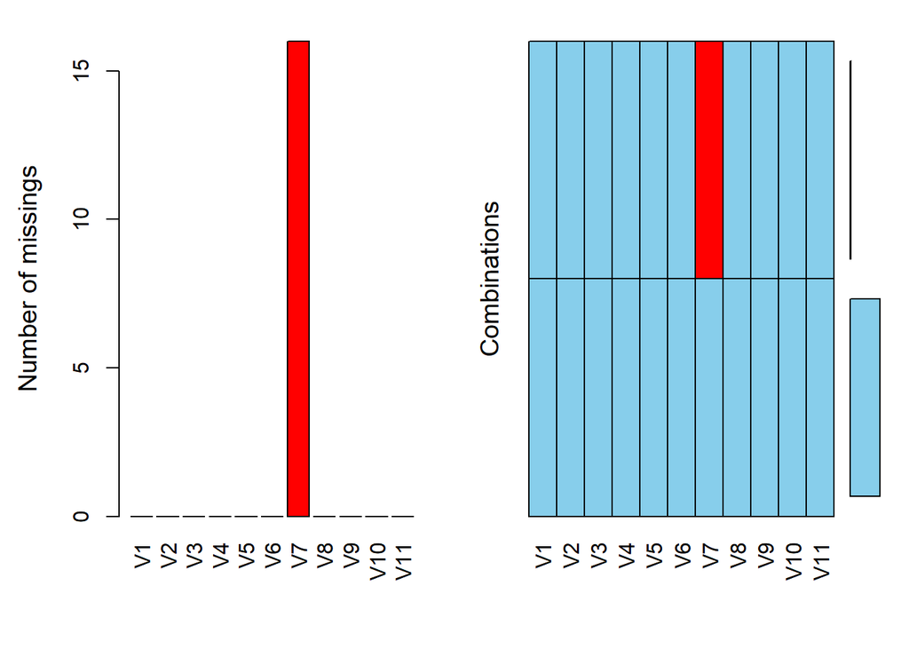

```r
data %>% VIM::aggr(prop = F)
names(data) <- c(
  "ID",
  "clumpThickness",
  "sizeUniformity",
  "shapeUniformity",
  "maginalAdhesion",
  "singleEpithelialCellSize",
  "bareNuclei",
  "blandChromatin",
  "normalNucleoli",
  "mitosis",
  "class"
)
```

# 3 划分训练集和测试集

```r
data %<>%
  select(-ID) %>%
  mutate(class = factor(class))

data %>% dim()
```

```
## [1] 699  10
```

```r
data %>% is.na() %>% sum()
```

```
## [1] 16
```

```r
library(caret)
id <- createDataPartition(data$class,p = 0.7,list = FALSE)
data_train <- data[id,]
data_test <- data[-id,]
```

```r
table(data_train$class)
```

```
##
##   2   4
## 321 169
```

```r
table(data_test$class)
```

```
##
##   2   4
## 137  72
```

训练集将用于建立**逻辑回归**、**决策树**、**条件推断树**、**随机森林**、**支持向量机**等分类模型，测试集用于评估各个模型的有效性。本章采用相同的数据集，因此可以直接比较各个方法的结果。

# 4 逻辑回归

R中的基本函数`glm()`可用于拟合逻辑回归模型。`glm()函数`自动将预测变量中的分类变量编码为相应的虚拟变量。威斯康星乳腺癌数据中的全部预测变量都是数值变量，因此不必要对其编码。下面给出R中逻辑回归流程。

```r
fit_logis <- glm(class ~ .,
                 data = data_train,
                 family = binomial())
summary(fit_logis)
```

```
##
## Call:
## glm(formula = class ~ ., family = binomial(), data = data_train)
##
## Deviance Residuals:
##      Min        1Q    Median        3Q       Max
## -2.46918  -0.06467  -0.02932   0.00574   1.90868
##
## Coefficients:
##                          Estimate Std. Error z value Pr(>|z|)
## (Intercept)              -12.7539     2.2069  -5.779 7.51e-09 ***
## clumpThickness             0.7597     0.2517   3.018  0.00255 **
## sizeUniformity             0.1955     0.3453   0.566  0.57129
## shapeUniformity            0.5323     0.3931   1.354  0.17569
## maginalAdhesion            0.3964     0.1648   2.406  0.01614 *
## singleEpithelialCellSize  -0.0389     0.2089  -0.186  0.85222
## bareNuclei                 0.2271     0.1236   1.837  0.06617 .
## blandChromatin             0.7431     0.2884   2.577  0.00998 **
## normalNucleoli             0.2145     0.1537   1.396  0.16276
## mitosis                    0.5247     0.6162   0.852  0.39446
## ---
## Signif. codes:  0 '***' 0.001 '**' 0.01 '*' 0.05 '.' 0.1 ' ' 1
##
## (Dispersion parameter for binomial family taken to be 1)
##
##     Null deviance: 618.587  on 477  degrees of freedom
## Residual deviance:  50.212  on 468  degrees of freedom
##   (12 observations deleted due to missingness)
## AIC: 70.212
##
## Number of Fisher Scoring iterations: 9
```

```r
fit_logis %>% stargazer::stargazer(type = "text")
```

```
##
## ====================================================
##                              Dependent variable:
##                          ---------------------------
##                                     class
## ----------------------------------------------------
## clumpThickness                    0.760***
##                                    (0.252)
##
## sizeUniformity                      0.195
##                                    (0.345)
##
## shapeUniformity                     0.532
##                                    (0.393)
##
## maginalAdhesion                    0.396**
##                                    (0.165)
##
## singleEpithelialCellSize           -0.039
##                                    (0.209)
##
## bareNuclei                         0.227*
##                                    (0.124)
##
## blandChromatin                    0.743***
##                                    (0.288)
##
## normalNucleoli                      0.215
##                                    (0.154)
##
## mitosis                             0.525
##                                    (0.616)
##
## Constant                         -12.754***
##                                    (2.207)
##
## ----------------------------------------------------
## Observations                         478
## Log Likelihood                     -25.106
## Akaike Inf. Crit.                  70.212
## ====================================================
## Note:                    *p<0.1; **p<0.05; ***p<0.01
```

```r
pred_logis <- predict(fit_logis, data_test, type="response")
pred_logis %>% head()
```

```
##            1            3            4            5            8           11
## 0.0088950218 0.0024585264 0.9556486473 0.0091917712 0.0015620168 0.0004466278
```

```r
logit.pred <- factor(pred_logis > .5,
                     levels = c(FALSE, TRUE),
                     labels = c("2", "4"))

table(data_test$class,
      logit.pred,
      dnn = c("Actual", "Predicted"))
```

```
##       Predicted
## Actual   2   4
##      2 129   4
##      4   7  65
```

```r
confusionMatrix(data_test$class,logit.pred)
```

```
## Confusion Matrix and Statistics
##
##           Reference
## Prediction   2   4
##          2 129   4
##          4   7  65
##
##                Accuracy : 0.9463
##                  95% CI : (0.906, 0.9729)
##     No Information Rate : 0.6634
##     P-Value [Acc > NIR] : <2e-16
##
##                   Kappa : 0.8811
##
##  Mcnemar's Test P-Value : 0.5465
##
##             Sensitivity : 0.9485
##             Specificity : 0.9420
##          Pos Pred Value : 0.9699
##          Neg Pred Value : 0.9028
##              Prevalence : 0.6634
##          Detection Rate : 0.6293
##    Detection Prevalence : 0.6488
##       Balanced Accuracy : 0.9453
##
##        'Positive' Class : 2
##
```

在这种情况下，可用逐步逻辑回归生成一个包含更少解释变量的模型，其目的是通过增加或移除变量来得到一个更小的AIC值。具体到这一案例，可通过：

```r
fit_logis_reduce <- step(fit_logis)
```

# 5 决策树

**决策树**是数据挖掘领域中的常用模型。其基本思想是对预测变量进行二元分离，从而构造一棵可用于预测新样本单元所属类别的树。本节将介绍两类决策树：经典树和条件推断树。

## 5.1 经典决策树

R中的`rpart包`支持`rpart()函数`构造决策树，`prune()函数`对决策树进行剪枝。下面给出判别细胞为良性或恶性的决策树算法实现。

```r
library(rpart)
fit_rpart <- rpart(class ~ .,data = data_train,method = "class",
                   parms = list(split = "information"))
fit_rpart$cptable
```

```
##           CP nsplit rel error    xerror       xstd
## 1 0.78698225      0 1.0000000 1.0000000 0.06226029
## 2 0.07100592      1 0.2130178 0.2130178 0.03417389
## 3 0.02366864      2 0.1420118 0.1715976 0.03090756
## 4 0.01000000      3 0.1183432 0.1656805 0.03040292
```

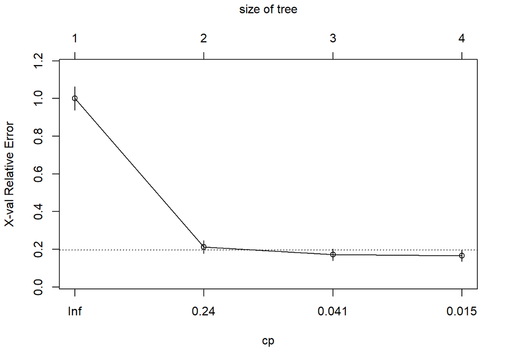

```r
plotcp(fit_rpart)
```

`rpart()`返回的`cptable值`中包括不同大小的树对应的预测误差，因此可用于辅助设定最终 的树的大小。其中，`复杂度参数（cp）`用于惩罚过大的树；树的大小即分支数（nsplit），有n 个分支的树将有n+1个终端节点； `rel_error栏`即训练集中各种树对应的误差；交叉验证误差 `（xerror）`即基于训练样本所得的10折交叉验证误差； `xstd栏`为交叉验证误差的标准差。

借助plotcp()函数可画出交叉验证误差与复杂度参数的关系图

```r
fit_rpart_prune <- prune(fit_rpart,cp = 0.125)
fit_rpart_prune
```

```
## n= 490
##
## node), split, n, loss, yval, (yprob)
##       * denotes terminal node
##
## 1) root 490 169 2 (0.65510204 0.34489796)
##   2) sizeUniformity< 2.5 299   7 2 (0.97658863 0.02341137) *
##   3) sizeUniformity>=2.5 191  29 4 (0.15183246 0.84816754) *
```

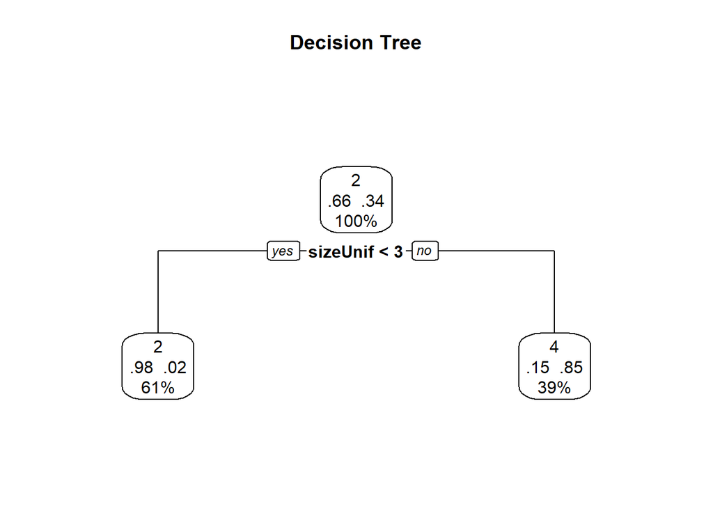

```r
library(rpart.plot)
prp(
  fit_rpart_prune,
  type = 2,
  extra = 104,
  fallen.leaves = TRUE,
  main = "Decision Tree"
)
```

```r
fit_rpart_prune_pred <- predict(fit_rpart_prune,data_test,
                                type = "class")
confusionMatrix(data_test$class,fit_rpart_prune_pred)
```

```
## Confusion Matrix and Statistics
##
##           Reference
## Prediction   2   4
##          2 125  12
##          4   5  67
##
##                Accuracy : 0.9187
##                  95% CI : (0.873, 0.9519)
##     No Information Rate : 0.622
##     P-Value [Acc > NIR] : <2e-16
##
##                   Kappa : 0.824
##
##  Mcnemar's Test P-Value : 0.1456
##
##             Sensitivity : 0.9615
##             Specificity : 0.8481
##          Pos Pred Value : 0.9124
##          Neg Pred Value : 0.9306
##              Prevalence : 0.6220
##          Detection Rate : 0.5981
##    Detection Prevalence : 0.6555
##       Balanced Accuracy : 0.9048
##
##        'Positive' Class : 2
##
```

## 5.2 条件推断树

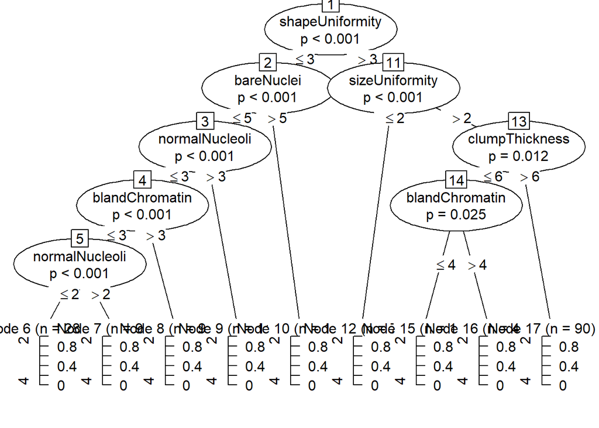

```r
fit_ctree <- ctree(class ~ .,data = data_train)
plot(fit_ctree)
```

```r
fit_ctree_pred <- predict(fit_ctree,data_test,type = "response")
confusionMatrix(fit_ctree_pred,data_test$class)
```

```
## Confusion Matrix and Statistics
##
##           Reference
## Prediction   2   4
##          2 130   4
##          4   7  68
##
##                Accuracy : 0.9474
##                  95% CI : (0.9078, 0.9734)
##     No Information Rate : 0.6555
##     P-Value [Acc > NIR] : <2e-16
##
##                   Kappa : 0.8846
##
##  Mcnemar's Test P-Value : 0.5465
##
##             Sensitivity : 0.9489
##             Specificity : 0.9444
##          Pos Pred Value : 0.9701
##          Neg Pred Value : 0.9067
##              Prevalence : 0.6555
##          Detection Rate : 0.6220
##    Detection Prevalence : 0.6411
##       Balanced Accuracy : 0.9467
##
##        'Positive' Class : 2
##
```

值得注意的是，对于**条件推断树**来说，剪枝不是必需的，其生成过程相对更自动化一些。另外， `party包`也提供了许多图像参数。

尽管在这个例子中，**传统决策树**和**条件推断树**的准确度比较相似，但有时它们可能会很不一 样。下一节中，我们将生成并组合大量决策树，从而对样本单元进行分类。

# 6 随机森林

随机森林的算法涉及对样本单元和变量进行抽样，从而生成大量决策树。对每个样本单元来 说，所有决策树依次对其进行分类。所有决策树预测类别中的众数类别即为随机森林所预测的这 一样本单元的类别。

生成树时没有用到的样本点所对应的类别可由生成的树估计，与其真实类别比较即可得到袋 外预测（out-of-bag， OOB）误差。无法获得验证集时，这是随机森林的一大优势。随机森林算 法可计算变量的相对重要程度

```r
library(randomForest)
fit_forest <- randomForest(class ~ .,
                           data = data_train,
                           na.action = na.roughfix,
                           importance = TRUE)
fit_forest
```

```
##
## Call:
##  randomForest(formula = class ~ ., data = data_train, importance = TRUE,      na.action = na.roughfix)
##                Type of random forest: classification
##                      Number of trees: 500
## No. of variables tried at each split: 3
##
##         OOB estimate of  error rate: 3.06%
## Confusion matrix:
##     2   4 class.error
## 2 312   9  0.02803738
## 4   6 163  0.03550296
```

```r
importance(fit_forest,type = 2)
```

```
##                          MeanDecreaseGini
## clumpThickness                  10.330017
## sizeUniformity                  56.423184
## shapeUniformity                 52.988106
## maginalAdhesion                  7.232984
## singleEpithelialCellSize        17.847822
## bareNuclei                      27.721257
## blandChromatin                  32.117762
## normalNucleoli                  15.138806
## mitosis                          1.329619
```

```r
fit_forest_pred <- predict(fit_forest,data_test)
confusionMatrix(fit_forest_pred,data_test$class)
```

```
## Confusion Matrix and Statistics
##
##           Reference
## Prediction   2   4
##          2 129   4
##          4   4  68
##
##                Accuracy : 0.961
##                  95% CI : (0.9246, 0.983)
##     No Information Rate : 0.6488
##     P-Value [Acc > NIR] : <2e-16
##
##                   Kappa : 0.9144
##
##  Mcnemar's Test P-Value : 1
##
##             Sensitivity : 0.9699
##             Specificity : 0.9444
##          Pos Pred Value : 0.9699
##          Neg Pred Value : 0.9444
##              Prevalence : 0.6488
##          Detection Rate : 0.6293
##    Detection Prevalence : 0.6488
##       Balanced Accuracy : 0.9572
##
##        'Positive' Class : 2
##
```

`randomForest包`根据传统决策树生成随机森林，而`party包`中的`cforest()函数`则可基于条件推断树生成随机森林。*当预测变量间高度相关时，基于条件推断树的随机森林可能效果更好*。相较于其他分类方法，随机森林的分类准确率通常更高。另外，随机森林算法**可处理大规模问题**（即多样本单元、多变量），可处理训练集中**有大量缺失值**的数据，也可应对变量远多于样本单元的数据。可计算袋外预测误差（OOB error）、**度量变量重要性**也是随机森林的两个明显优势。

随机森林的一个明显缺点是**分类方法（此例中相当于500棵决策树）较难理解和表达**。另外，我们需要存储整个随机森林以对新样本单元分类

# 7 支持向量机

**支持向量机（SVM）**是一类可用于**分类和回归**的有监督机器学习模型。其流行归功于两个方面：

- 一方面，他们可输出较准确的预测结果；
- 另一方面，模型基于较优雅的数学理论。

本章将介绍支持向量机在二元分类问题中的应用。

SVM旨在在多维空间中找到一个**能将全部样本单元分成两类的最优平面**，这一平面应使两类中距离最近的点的间距（margin）尽可能大，在间距边界上的点被称为**支持向量**（support vector，它们决定间距），分割的超平面位于间距的中间。

对于一个N维空间（即N个变量）来说，**最优超平面**（即线性决策面， linear decision surface）为N–1维。当变量数为2时，曲面是一条直线；当变量数为3时，曲面是一个平面；当变量数为10 时，曲面就是一个九维的超平面。当然，这并不是太好想象。

```r
library(e1071)
fit_svm <- svm(class ~ .,data = data_train)
fit_svm
```

```
##
## Call:
## svm(formula = class ~ ., data = data_train)
##
##
## Parameters:
##    SVM-Type:  C-classification
##  SVM-Kernel:  radial
##        cost:  1
##
## Number of Support Vectors:  67
```

```r
fit_svm_pred <- predict(fit_svm,na.omit(data_test))
confusionMatrix(fit_svm_pred,na.omit(data_test)$class)
```

```
## Confusion Matrix and Statistics
##
##           Reference
## Prediction   2   4
##          2 128   2
##          4   5  70
##
##                Accuracy : 0.9659
##                  95% CI : (0.9309, 0.9862)
##     No Information Rate : 0.6488
##     P-Value [Acc > NIR] : <2e-16
##
##                   Kappa : 0.9258
##
##  Mcnemar's Test P-Value : 0.4497
##
##             Sensitivity : 0.9624
##             Specificity : 0.9722
##          Pos Pred Value : 0.9846
##          Neg Pred Value : 0.9333
##              Prevalence : 0.6488
##          Detection Rate : 0.6244
##    Detection Prevalence : 0.6341
##       Balanced Accuracy : 0.9673
##
##        'Positive' Class : 2
##
```

由于方差较大的预测变量通常对SVM的生成影响更大，`svm()函数`默认在生成模型前对每个变量标准化，使其均值为0、标准差为1。从结果来看， SVM的预测准确率不错.

*svm()函数*默认通过**径向基函数**（Radial Basis Function， RBF）将样本单元投射到高维空间。**一般来说RBF核是一个比较好的选择**，因为它是一种非线性投影，可以应对类别标签与预测变量 间的非线性关系。

在用带RBF核的SVM拟合样本时，两个参数可能影响最终结果： **gamma和成本（cost）**。 gamma是核函数的参数，控制分割超平面的形状。gamma越大，通常导致支持向量越多。我们也可将gamma看作控制训练样本“到达范围”的参数，即gamma越大意味着训练样本到达范围越广，而越小则意味着到达范围越窄。**gamma必须大于0**。

**成本参数**代表犯错的成本。一个**较大的成本**意味着模型对误差的惩罚更大，从而将生成一个更复杂的分类边界，对应的训练集中的误差也会更小，但**也意味着可能存在过拟合问题**，即对新样本单元的预测误差可能很大。较小的成本意味着分类边界更平滑，但可能会导致欠拟合。与gamma一样，成本参数也恒为正。

*`svm()函数`*默认设置**gamma为预测变量个数的倒数**，**成本参数为1**。不过gamma与成本参数的不同组合可能生成更有效的模型。在建模时，我们可以尝试变动参数值建立不同的模型，但利用格点搜索法可能更有效。可以通过`tune.svm()`对每个参数设置一个候选范围， tune.svm()函数对每一个参数组合生成一个SVM模型，并输出在每一个参数组合上的表现。

```r
fit_svm_tuned <- tune.svm(
  class ~ .,
  data = data_train,
  gamma = 10 ^ (-6:1),
  cost = 10 ^ (-10:10)
)
fit_svm_tuned
```

```
##
## Parameter tuning of 'svm':
##
## - sampling method: 10-fold cross validation
##
## - best parameters:
##  gamma cost
##   0.01    1
##
## - best performance: 0.02266337
```

```r
fit_svm_modify <- svm(class ~ .,data = data_train,gamma = 0.01,cost = 1)
fit_svm_pred <- predict(fit_svm_modify,data_test %>% na.omit())
confusionMatrix(fit_svm_pred,data_test %>% na.omit() %>% pull(class))
```

```
## Confusion Matrix and Statistics
##
##           Reference
## Prediction   2   4
##          2 128   4
##          4   5  68
##
##                Accuracy : 0.9561
##                  95% CI : (0.9183, 0.9797)
##     No Information Rate : 0.6488
##     P-Value [Acc > NIR] : <2e-16
##
##                   Kappa : 0.904
##
##  Mcnemar's Test P-Value : 1
##
##             Sensitivity : 0.9624
##             Specificity : 0.9444
##          Pos Pred Value : 0.9697
##          Neg Pred Value : 0.9315
##              Prevalence : 0.6488
##          Detection Rate : 0.6244
##    Detection Prevalence : 0.6439
##       Balanced Accuracy : 0.9534
##
##        'Positive' Class : 2
##
```

如前所述，由于SVM适用面比较广，它目前是很流行的一种模型。 SVM也可以**应用于变量数远多于样本单元数**的问题，而这类问题在生物医药行业很常见，因为在DNA微序列的基因表示中，变量数通常比可用样本量的个数高1~2个量级。

与随机森林类似， **SVM的一大缺点**是分类准则比较难以理解和表述(精度高，可解释性差)。 SVM从本质上来说是一个黑盒子。另外，**SVM在对大量样本建模时不如随机森林**，但只要建立了一个成功的模型，在对新样本分类时就没有问题了。

# 8 选择预测效果最好的解

我们通过**几种有监督机器学习方法**对细针抽吸活检细胞进行分类，但如何从中选出最准确的方法呢？首先需要在二分类情况下定义准确。

最常用的一个统计量是**准确率**（accuracy），即分类器是否总能正确划分样本单元。不过，尽 管准确率承载的信息量很大，这一指标仍不足以选出最准确的方法。我们还需要其他信息来评估各种分类方法的有效性。

假设我们现在需要**判别一个人是否患有精神分裂症**。精神分裂症是一种极少见的生理障碍，人群中的患病率约为1%。**如果一种分类方法将全部人都判为未患病**，则这一分类器的准确率将达到99%，但它会把所有患精神分裂症的人都判别成健康人。从这个角度来说它显然不是一个好的分类器。因此，在准确率之外，你一般还应该问问以下问题。

- 患有精神分裂症的人中有多大比例成功鉴别？
- 未患病的人中有多大比例成功鉴别？
- 如果一个人被鉴别为精神分裂症患者，这个判别有多大概率是准确的？
- 如果一个人被鉴别为未患病，这个判别又有多大概率是准确的？

上述问题涉及一个分类器的**敏感度**（sensitivity）、**特异性**（sensitivity）、**正例命中率**（positive predictive power）和**负例命中率**（negative predictive power）。

- **敏感度**: 正类的样本单元被成功预测的概率，也叫正例覆盖率（ true positive）或召回率（ recall）
- **特异性**: 负类的样本单元被成功预测的概率，也叫负例覆盖率（ true negative）
- **正例命中率**: 被预测为正类的样本单元中，预测正确的样本单元占比，也叫精确度（ precision）
- **负例命中率**: 被预测为负类的样本单元中，预测正确的样本单元占比
- **准确率**: 被正确分类的样本单元所占比重，也叫ACC

```r
confusionMatrix(fit_rpart_prune_pred,data_test$class)[[4]] %>% enframe()
```

| name | value |
| --- | --- |
| Sensitivity | 0.9124088 |
| Specificity | 0.9305556 |
| Pos Pred Value | 0.9615385 |
| Neg Pred Value | 0.8481013 |
| Precision | 0.9615385 |
| Recall | 0.9124088 |
| F1 | 0.9363296 |
| Prevalence | 0.6555024 |
| Detection Rate | 0.5980861 |
| Detection Prevalence | 0.6220096 |

[output cut: 1 more lines]

```r
confusionMatrix(fit_ctree_pred,data_test$class)[[4]] %>% enframe()
```

| name | value |
| --- | --- |
| Sensitivity | 0.9489051 |
| Specificity | 0.9444444 |
| Pos Pred Value | 0.9701493 |
| Neg Pred Value | 0.9066667 |
| Precision | 0.9701493 |
| Recall | 0.9489051 |
| F1 | 0.9594096 |
| Prevalence | 0.6555024 |
| Detection Rate | 0.6220096 |
| Detection Prevalence | 0.6411483 |

[output cut: 1 more lines]

```r
confusionMatrix(fit_forest_pred,data_test$class)[[4]] %>% enframe()
```

| name | value |
| --- | --- |
| Sensitivity | 0.9699248 |
| Specificity | 0.9444444 |
| Pos Pred Value | 0.9699248 |
| Neg Pred Value | 0.9444444 |
| Precision | 0.9699248 |
| Recall | 0.9699248 |
| F1 | 0.9699248 |
| Prevalence | 0.6487805 |
| Detection Rate | 0.6292683 |
| Detection Prevalence | 0.6487805 |

[output cut: 1 more lines]

```r
confusionMatrix(fit_svm_pred,data_test %>% na.omit() %>% pull(class))[[4]] %>%
  enframe()
```

| name | value |
| --- | --- |
| Sensitivity | 0.9624060 |
| Specificity | 0.9444444 |
| Pos Pred Value | 0.9696970 |
| Neg Pred Value | 0.9315068 |
| Precision | 0.9696970 |
| Recall | 0.9624060 |
| F1 | 0.9660377 |
| Prevalence | 0.6487805 |
| Detection Rate | 0.6243902 |
| Detection Prevalence | 0.6439024 |

[output cut: 1 more lines]

```r
confusionMatrix(fit_rpart_prune_pred,data_test$class)[[4]] %>%
  enframe(value = "rpart") %>%
  bind_cols(confusionMatrix(fit_ctree_pred,data_test$class)[[4]] %>%
              enframe(value = "ctree")) %>%
  bind_cols(confusionMatrix(fit_forest_pred,data_test$class)[[4]] %>%
              enframe(value = "forest")) %>%
  bind_cols(confusionMatrix(fit_svm_pred,data_test %>%
                              na.omit() %>% pull(class))[[4]] %>%
              enframe(value = "Svm")) -> data_compare
```

```
## * name -> name...1
## * name -> name...3
```

```
## * name -> name...5
```

```
## * name -> name...7
```

```r
data_compare %>%
  select(name...1,rpart,ctree,forest,Svm) %>%
  rename(name = name...1) %>%
  datatable()
```

|  | name | rpart | ctree | forest | Svm |
| --- | --- | --- | --- | --- | --- |
| 1 | Sensitivity | 0.912408759124088 | 0.948905109489051 | 0.969924812030075 | 0.962406015037594 |
| 2 | Specificity | 0.930555555555556 | 0.944444444444444 | 0.944444444444444 | 0.944444444444444 |
| 3 | Pos Pred Value | 0.961538461538462 | 0.970149253731343 | 0.969924812030075 | 0.96969696969697 |
| 4 | Neg Pred Value | 0.848101265822785 | 0.906666666666667 | 0.944444444444444 | 0.931506849315068 |
| 5 | Precision | 0.961538461538462 | 0.970149253731343 | 0.969924812030075 | 0.96969696969697 |
| 6 | Recall | 0.912408759124088 | 0.948905109489051 | 0.969924812030075 | 0.962406015037594 |
| 7 | F1 | 0.936329588014981 | 0.959409594095941 | 0.969924812030075 | 0.966037735849057 |
| 8 | Prevalence | 0.655502392344498 | 0.655502392344498 | 0.648780487804878 | 0.648780487804878 |
| 9 | Detection Rate | 0.598086124401914 | 0.62200956937799 | 0.629268292682927 | 0.624390243902439 |
| 10 | Detection Prevalence | 0.62200956937799 | 0.641148325358852 | 0.648780487804878 | 0.64390243902439 |

[output cut: 1 more lines]

在这个案例中，这些分类器（逻辑回归、传统决策树、条件推断树、随机森林和支持向量机）都表现得相当不错。不过在现实中并不总是这样。

我们也可以从**特异性**和**敏感度**的权衡中提高分类的性能，但这不在本书的范围之内。在逻辑回归模型中，`predict()函数`可以估计一个样本单元为恶性组织的概率。如果这一概率值大于0.5，则分类器会把这一样本单元判为恶性。**这个0.5即阈值（threshold）**或门槛值（cutoff value）。通过变动这一阈值，我们可以通过牺牲分类器的特异性来增加其敏感度。这同样适用于决策树、随机森林和支持向量机（尽管语句写法上会有差别）。

**变动阈值**可能带来的影响可以通过ROC（Receiver Operating Characteristic）曲线来进一步观察。**ROC曲线**可对一个区间内的门槛值画出特异性和敏感度之间的关系，然后我们就能针对特定问题选择特异性和敏感度的最佳组合。许多R包都可以画ROC曲线，如`ROCR`、`pROC`等。这些R包中的函数能帮助我们在面对不同问题时，通过比较不同算法的ROC曲线选择最有效的算法。细节见Kuhn&Johnson（2013），更详尽的讨论见Fawcett（2005）。

# 9 用`rattle包`进行数据挖掘

Rattle（R Analytic Tool to Learn Easily）为R语言用户提供了一个可做数据分析的图像式交互界面（GUI）。这样，本章提及的很多函数以及未提及的其他无监督或有监督的学习方法，都可以通过鼠标点击的方式操作。 Rattle也可以实现数据转换和评分等功能，并提供了可用于评估模型的一系列数据可视化工具。

为了节约时间和存储空间，**安装rattle**时将默认同时安装几个必需的基础包。其他包将在我们需要用到相关分析方法时安装。这样我们在操作中可能会不时碰到需要安装缺失程序包的提醒；如果选择“是”， R会从CRAN上下载安装所需的程序包。

我们也可以指定**训练集**、**验证集**和**测试集**中的样本比重。数据分析的一般流程是通过*训练集建立模型，基于验证集调节参数，在测试集上评价模型*。Rattle对数据集的默认划分是70/15/15，设定随机种子为42。

这里只将全部数据分成**训练集**和**验证集**，在划分文本框（Partition text box）中输入70/30/0，设定种子为1234，再单击执行。

**Rattle的一个巨大优势**是可以对同一数据集拟合出不同模型，并通过评价选项卡来直接比较各个模型。我们可以在选项卡中指定**想要比较的几种方法，然后单击执行**。另外，执行过程中调用的所有R命令都可以在**日志（Log）选项卡**中看到，还可以将它们输出到一个文本文件中来实现重复调用。

# 10 小结

本章介绍了一系列用于**二分类的机器学习方法**，包括**逻辑回归分类方法**、**传统决策树**、**条件推断树**、集成性的**随机森林**以及越来越流行的**支持向量机**。最后介绍了**Rattle**，它为数据挖掘提供了一个图形用户界面，使用户可以通过鼠标点击的方式调用相关的函数。Rattle在比较多个分类模型时格外有用。由于它可在日志文件中生成可重用的R代码，也为我们学习R中的许多预测分析函数的语法提供了机会。

本章介绍的方法复杂度各异。数据挖掘者一般会尝试一些相对简单的方法（如逻辑回归、决 策树）和一些复杂的、黑箱式的方法（如随机森林、支持向量机）。如果与简单的方法相比，复杂方法在预测效果方面并没有显著提升，则我们一般会选择较简单的方法。